# Getting Start with Git

# and GitHub for R Users

### Saghir Bashir<br><br>24th May 2019

# Relax

# Experiment

# Make Mistakes

# Learn

# Enjoy

# Outline

## Motivation

## Discover GitHub

## Git to GitHub

## Summary

# Motivation

# Why?

# Developing an R Program

### R Program

```
# Thesis Project Data Cleaning
library(data.table)
library(here)

tdata <- fread(here("mydata.csv"))

# ... some data cleaning code here ...
```

### Processing R Program

1. Save as **"thesis-data.R"**

# Developing an R Program

### R Program

```r
# Thesis Project Data Cleaning
library(data.table)
library(here)

tdata <- fread(here("mydata.csv"))

# ... some data cleaning code here ...

# ... some more data cleaning code here ...
```

### Processing R Program

1. Save as "thesis-data.R"
2. Overwrite **"thesis-data.R"**

# Developing an R Program

### R Program

```r
# Thesis Project Data Cleaning
library(data.table)
library(here)

tdata <- fread(here("mydata.csv"))

# ... some data cleaning code here ...

# ... some more data cleaning code here ...

# ... summary statistics to check data ...
```

### Processing R Program

1. Save as "thesis-data.R"
2. Overwrite "thesis-data.R"
3. Overwrite **"thesis-data.R"** again

# Developing an R Program

### R Program

```r
# Thesis Project Data Cleaning
library(data.table)
library(here)

tdata <- fread(here("mydata.csv"))

# ... some data cleaning code here ...

# ... MODIFY data cleaning code here ...

# ... summary statistics to check data ...
```

### Processing R Program

1. Save as "thesis-data.R"
2. Overwrite "thesis-data.R"
3. Overwrite "thesis-data.R" again
4. Overwrite **"thesis-data.R"** with modification

# Developing an R Program

### R Program

```r
# Thesis Project Data Cleaning
library(data.table)
library(here)

tdata <- fread(here("mydata.csv"))

# ... some data cleaning code here ...

# ... MODIFY data cleaning code here ...

# ... summary statistics to check data ...

# !!! Modified code messed up summary statitics !!!

# !!! Previous code worked better  !!!
```

### Processing R Program

1. Save as "thesis-data.R"
2. Overwrite "thesis-data.R"
3. Overwrite "thesis-data.R" again
4. Overwrite "thesis-data.R" with modification
5. Redo work that you did before

# R Program - Saving Versions

### R Program

```r
# Thesis Project Data Cleaning
library(data.table)
library(here)

tdata <- fread(here("mydata.csv"))

# ... some data cleaning code here ...
```

### Processing R Program

1. Save as **"thesis-data-01.R"**

# R Program - Saving Versions

### R Program

```r
# Thesis Project Data Cleaning
library(data.table)
library(here)

tdata <- fread(here("mydata.csv"))

# ... some data cleaning code here ...

# ... some more data cleaning code here ...
```

### Processing R Program

1. Save as "thesis-data-01.R"
2. Save as **"thesis-data-02.R"**

# R Program - Saving Versions

### R Program

```r
# Thesis Project Data Cleaning
library(data.table)
library(here)

tdata <- fread(here("mydata.csv"))

# ... some data cleaning code here ...

# ... some more data cleaning code here ...

# ... summary statistics to check data ...
```

### Processing R Program

1. Save as "thesis-data-01.R"
2. Save as "thesis-data-02.R"
3. Save as **"thesis-data-03.R"**

# R Program - Saving Versions

### R Program

```r
# Thesis Project Data Cleaning
library(data.table)
library(here)

tdata <- fread(here("mydata.csv"))

# ... some data cleaning code here ...

# ... MODIFY data cleaning code here ...

# ... summary statistics to check data ...
```

### Processing R Program

1. Save as "thesis-data-01.R"
2. Save as "thesis-data-02.R"
3. Save as "thesis-data-03.R"
4. Save as **"thesis-data-04.R"**

# R Program - Saving Versions

### R Program

```r
# Thesis Project Data Cleaning
library(data.table)
library(here)

tdata <- fread(here("mydata.csv"))

# ... some data cleaning code here ...

# ... MODIFY data cleaning code here ...

# ... summary statistics to check data ...

# !!! Modified code messed up summary statitics !!!

# ... I remember I can go back version 03 !!!

# ... Fixed, send final version to supervisor, ...
```

### Processing R Program

1. Save as "thesis-data-01.R"
2. Save as "thesis-data-02.R"
3. Save as "thesis-data-03.R"
4. Save as "thesis-data-04.R"
5. Save as **"thesis-data-Final.R"**
    + Send to supervisor

# R Program - Saving Versions

### R Program

```r
# Thesis Project Data Cleaning
library(data.table)
library(here)

tdata <- fread(here("mydata.csv"))

# ... some data cleaning code here ...

# ... MODIFY data cleaning code here ...

# ... summary statistics to check data ...

# !!! Modified code messed up summary statitics !!!

# ... Fixed, send final version to supervisor, ...

# ... and real life continues ...
```

### Processing R Program

1. Save as "thesis-data-01.R"
2. Save as "thesis-data-02.R"
3. Save as "thesis-data-03.R"
4. Save as "thesis-data-04.R"
5. Save as "thesis-data-Final.R"
6. ... **"thesis-data-Final-Sup.R"**
    + Received from supervisor
7. ... **"thesis-data-Final-Sup-ME.R"**
8. ...

# Six months later...

# The FUTURE YOU

### Continues on the project.

### Project needs updating.

### Receive updated data.

### Discover an error.

### ...

### Continue from where?

+ `thesis-data-01.R`
+ `thesis-data-02.R`
+ `thesis-data-03.R`
+ `thesis-data-04.R`
+ `thesis-data-Final-Final.R`
+ `thesis-data-Final-Last.R`
+ `thesis-data-Final-Sup-ME-minor.R`
+ `thesis-data-Final-Sup-ME.R`
+ `thesis-data-Final-Sup.R`
+ `thesis-data-Final.R`
+ `thesis-data-Final2.R`
+ `...`

# Danger of Using File Date & Time

## They are not reliable

### What do they really represent? Modified? Openned?

### Did you modify the wrong file before?

### Was the true latest file deleted?

# Other Problems

## What changed between files?

## What needs to be done?

## What issues are there?

## How can multiple people collaborate?

...

# Git & GitHub

## Track changes

## Share your work

## Collaborate

## Track issues

# Discover GitHub

# Objectives

## Learn GitHub through observation

## What do you observe?

## What do you understand?

## Your understanding - not about being right

### https://github.com/saghirb/Getting-Started-in-R

[figure not shown]

# Discover a GitHub Repository

### General

+ What file types do you recognise?
+ What is at the end of the main page?
    + How is "README.md" linked?

### Click on "Commit"

+ When was the repository created?
+ When was the last "commit"?
+ When were all the R chunks labelled?
    - Click on the link. What do you see?
+ What do you think a "commit" is?

### Issues

+ How many issues are open? Closed?
+ Click on one open and one closed issue.
    - What is the difference?

### Forks

+ How many forks are there?
+ What is a "fork"?
    + Hint: click on one of the forks.

# Sign up to GitHub*

# https://github.com/

`*` If you do not agree with the terms and conditions let me know.

# Git, GitHub & RStudio

# GitHub is built on Git.

# Let's start by using Git in RStudio.

# Then we will link back to GitHub.

# Install git

## https://git-scm.com/downloads

## Accept default installation options

# IMPORTANT: R Setup

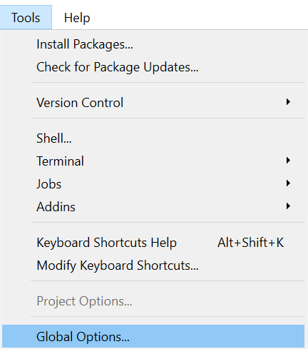

[figure not shown]

# RStudio Git Setup

[figure not shown]

[figure not shown]

# Git User Settings - Just Do Once

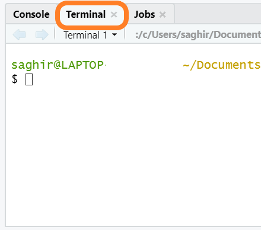

### Switch to the terminal tab & type:

```
git config --global user.name "Your Name"
git config --global user.email "email@example.com"
```

#### Note: Use the same email address as for GitHub

### Check Settings

```
git config --global
```

# We are ready to use Git with RStudio.

# Let's start a new project.

# New RStudio Project (i)

[figure not shown]

[figure not shown]

# New RStudio Project (ii)

[figure not shown]

# New RStudio Project (iii)

[figure not shown]

# New RStudio Project (iv)

[figure not shown]

# Working with Git in RStudio

## 1. Create an R file

## 2. Save ("commit") it using git

## 3. Modify the file and "commit" again

## 4. Save to your on-line GitHub account

# Create New R Markdown Document

[figure not shown]

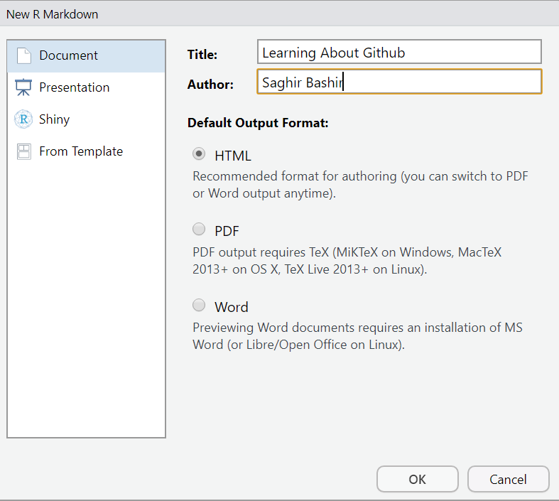

[figure not shown]

# Save R Markdown File

[figure not shown]

[figure not shown]

# "Commit" Untracked Files

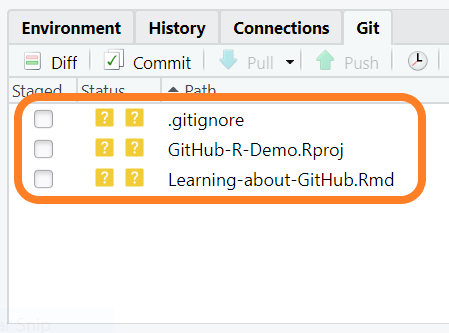

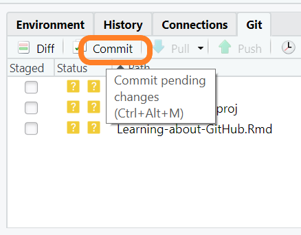

[figure not shown]

# Successful First Commit

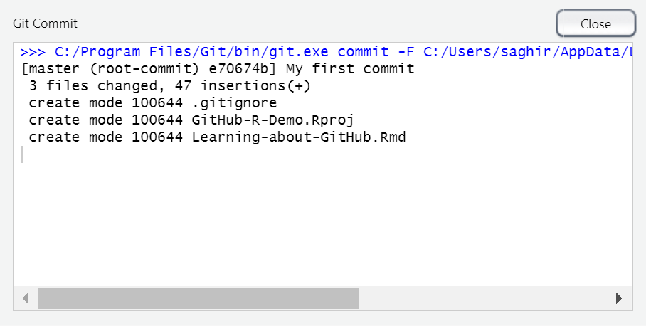

# Commit

# Your files are now a part of the

# Git history of this project.

# Git Panel Should be Clear

[figure not shown]

# Let's Modify Learning-about-GitHub.Rmd

# Then commit the changes...

[figure not shown]

# Knit the R Markdown File

[figure not shown]

# Rmd Modified & Files Untracked

[figure not shown]